# modeling_algorithm

```python
# Core Libraries
import pandas as pd
import numpy as np
import matplotlib.pyplot as plt
import matplotlib.ticker as mtick
import seaborn as sns
import shap

# Preprocessing
from sklearn.preprocessing import StandardScaler
from sklearn.decomposition import PCA
from sklearn.model_selection import train_test_split

# Models
from sklearn.svm import SVC, LinearSVC, LinearSVR
from sklearn.linear_model import LogisticRegression, LinearRegression
from sklearn.ensemble import RandomForestClassifier, RandomForestRegressor
from xgboost import XGBClassifier, XGBRegressor

# Evaluation Metrics
from sklearn.metrics import (
    mean_squared_error,
    r2_score,
    accuracy_score,
    precision_score,
    recall_score,
    f1_score,
    confusion_matrix,
    ConfusionMatrixDisplay
)

# Pipeline
from sklearn.pipeline import make_pipeline
```

```python
#read pre-processed data
df = pd.read_csv(r"C:\Users\Ochieng' Oginga\Documents\Post_S\Spring_2025\Data_Science_II\Project\Data\Oginga_Stage4.csv")

#show head
df.head()
```

|  | Name | City | State | Zip | Bank | BankState | ApprovalDate | ApprovalFY | Term | NoEmp | ... | Sector_Mining | Sector_Other Services | Sector_Professional Services | Sector_Public Admin | Sector_Real Estate | Sector_Retail Trade | Sector_Transportation | Sector_Unknown | Sector_Utilities | Sector_Wholesale Trade |
| --- | --- | --- | --- | --- | --- | --- | --- | --- | --- | --- | --- | --- | --- | --- | --- | --- | --- | --- | --- | --- | --- |
| 0 | CARVEL | APEX | NC | 27502 | STEARNS BK NATL ASSOC | MN | 7-Feb-06 | 2006 | 162 | 2 | ... | False | False | False | False | False | True | False | False | False | False |
| 1 | SUBWAY | LITTLE ROCK | AR | 72223 | HOPE FCU | MS | 7-Feb-06 | 2006 | 126 | 7 | ... | False | False | False | False | False | False | False | False | False | False |
| 2 | WEYLAND CORPORATION | CAMARILLO | CA | 93010 | WELLS FARGO BANK NATL ASSOC | SD | 7-Feb-06 | 2006 | 83 | 18 | ... | False | False | False | False | False | False | False | False | False | False |
| 3 | CHICAGO BRICK UNLIMITED INC | MIAMI | FL | 33186 | CITIBANK, N.A. | FL | 7-Feb-06 | 2006 | 84 | 4 | ... | False | False | False | False | False | False | False | False | False | False |
| 4 | RZI, INC. | NEW ORLEANS | LA | 70130 | BUSINESS RES. CAP. SPECIALTY B | LA | 7-Feb-06 | 2006 | 60 | 3 | ... | False | False | False | False | True | False | False | False | False | False |

5 rows × 46 columns

### size check

```python
df.shape
```

```
(572333, 46)
```

### Descriptive Analysis

a) Numeric descriptive statistics

```python
#get description of the data
df.describe(include='all')
```

|  | Name | City | State | Zip | Bank | BankState | ApprovalDate | ApprovalFY | Term | NoEmp | ... | Sector_Mining | Sector_Other Services | Sector_Professional Services | Sector_Public Admin | Sector_Real Estate | Sector_Retail Trade | Sector_Transportation | Sector_Unknown | Sector_Utilities | Sector_Wholesale Trade |
| --- | --- | --- | --- | --- | --- | --- | --- | --- | --- | --- | --- | --- | --- | --- | --- | --- | --- | --- | --- | --- | --- |
| count | 572333 | 572333 | 572333 | 572333.000000 | 572333 | 572333 | 572333 | 572333.000000 | 572333.000000 | 572333.000000 | ... | 572333 | 572333 | 572333 | 572333 | 572333 | 572333 | 572333 | 572333 | 572333 | 572333 |
| unique | 503960 | 26389 | 51 | NaN | 4599 | 55 | 4907 | NaN | NaN | NaN | ... | 2 | 2 | 2 | 2 | 2 | 2 | 2 | 2 | 2 | 2 |
| top | SUBWAY | LOS ANGELES | CA | NaN | BANK OF AMERICA NATL ASSOC | CA | 30-Jan-04 | NaN | NaN | NaN | ... | False | False | False | False | False | False | False | False | False | False |
| freq | 937 | 8412 | 82707 | NaN | 68797 | 78333 | 981 | NaN | NaN | NaN | ... | 571156 | 518318 | 517442 | 572235 | 560509 | 474753 | 551563 | 549492 | 571880 | 537222 |
| mean | NaN | NaN | NaN | 52526.476848 | NaN | NaN | NaN | 2004.824689 | 96.625847 | 8.801560 | ... | NaN | NaN | NaN | NaN | NaN | NaN | NaN | NaN | NaN | NaN |
| std | NaN | NaN | NaN | 31533.588428 | NaN | NaN | NaN | 2.982871 | 70.744067 | 43.751445 | ... | NaN | NaN | NaN | NaN | NaN | NaN | NaN | NaN | NaN | NaN |
| min | NaN | NaN | NaN | 0.000000 | NaN | NaN | NaN | 1994.000000 | 0.000000 | 0.000000 | ... | NaN | NaN | NaN | NaN | NaN | NaN | NaN | NaN | NaN | NaN |
| 25% | NaN | NaN | NaN | 22480.000000 | NaN | NaN | NaN | 2003.000000 | 60.000000 | 2.000000 | ... | NaN | NaN | NaN | NaN | NaN | NaN | NaN | NaN | NaN | NaN |
| 50% | NaN | NaN | NaN | 54112.000000 | NaN | NaN | NaN | 2005.000000 | 84.000000 | 4.000000 | ... | NaN | NaN | NaN | NaN | NaN | NaN | NaN | NaN | NaN | NaN |
| 75% | NaN | NaN | NaN | 83713.000000 | NaN | NaN | NaN | 2007.000000 | 102.000000 | 8.000000 | ... | NaN | NaN | NaN | NaN | NaN | NaN | NaN | NaN | NaN | NaN |
| max | NaN | NaN | NaN | 99999.000000 | NaN | NaN | NaN | 2014.000000 | 569.000000 | 8000.000000 | ... | NaN | NaN | NaN | NaN | NaN | NaN | NaN | NaN | NaN | NaN |

11 rows × 46 columns

i. Summary of numeric variables

```python
#get summary of the numeric variables
df.describe()
```

|  | Zip | ApprovalFY | Term | NoEmp | NewExist | CreateJob | RetainedJob | DisbursementGross | ChgOffPrinGr | GrAppv | SBA_Appv | ChgOffDate_binary | UrbanRural_binary | MIS_Status_Binary | IsFranchise | LowDoc_binary | RevLineCr_binary |
| --- | --- | --- | --- | --- | --- | --- | --- | --- | --- | --- | --- | --- | --- | --- | --- | --- | --- |
| count | 572333.000000 | 572333.000000 | 572333.000000 | 572333.000000 | 572333.000000 | 572333.000000 | 572333.000000 | 5.723330e+05 | 5.723330e+05 | 5.723330e+05 | 5.723330e+05 | 572333.000000 | 572333.000000 | 572333.000000 | 572333.000000 | 572333.000000 | 572333.000000 |
| mean | 52526.476848 | 2004.824689 | 96.625847 | 8.801560 | 1.285879 | 2.424426 | 5.958591 | 1.928716e+05 | 1.702337e+04 | 1.785447e+05 | 1.352192e+05 | 0.241809 | 0.183114 | 0.765161 | 0.055803 | 0.074114 | 0.334014 |
| std | 31533.588428 | 2.982871 | 70.744067 | 43.751445 | 0.453835 | 13.775755 | 24.015743 | 3.094678e+05 | 7.365140e+04 | 3.027037e+05 | 2.487573e+05 | 0.428179 | 0.386760 | 0.423898 | 0.229541 | 0.261957 | 0.471645 |
| min | 0.000000 | 1994.000000 | 0.000000 | 0.000000 | 0.000000 | 0.000000 | 0.000000 | 4.000000e+03 | 0.000000e+00 | 1.000000e+03 | 5.000000e+02 | 0.000000 | 0.000000 | 0.000000 | 0.000000 | 0.000000 | 0.000000 |
| 25% | 22480.000000 | 2003.000000 | 60.000000 | 2.000000 | 1.000000 | 0.000000 | 0.000000 | 3.500000e+04 | 0.000000e+00 | 2.500000e+04 | 1.300000e+04 | 0.000000 | 0.000000 | 1.000000 | 0.000000 | 0.000000 | 0.000000 |
| 50% | 54112.000000 | 2005.000000 | 84.000000 | 4.000000 | 1.000000 | 0.000000 | 2.000000 | 8.000000e+04 | 0.000000e+00 | 6.000000e+04 | 3.750000e+04 | 0.000000 | 0.000000 | 1.000000 | 0.000000 | 0.000000 | 0.000000 |
| 75% | 83713.000000 | 2007.000000 | 102.000000 | 8.000000 | 2.000000 | 2.000000 | 6.000000 | 2.000000e+05 | 0.000000e+00 | 1.800000e+05 | 1.275000e+05 | 0.000000 | 0.000000 | 1.000000 | 0.000000 | 0.000000 | 1.000000 |
| max | 99999.000000 | 2014.000000 | 569.000000 | 8000.000000 | 2.000000 | 5085.000000 | 9500.000000 | 1.144632e+07 | 2.223766e+06 | 5.472000e+06 | 5.472000e+06 | 1.000000 | 1.000000 | 1.000000 | 1.000000 | 1.000000 | 1.000000 |

ii. Summary for categorical variables

```python
#summary of categorical variables
df.describe(include=[object])
```

|  | Name | City | State | Bank | BankState | ApprovalDate | DisbursementDate | BalanceGross |
| --- | --- | --- | --- | --- | --- | --- | --- | --- |
| count | 572333 | 572333 | 572333 | 572333 | 572333 | 572333 | 572333 | 572333 |
| unique | 503960 | 26389 | 51 | 4599 | 55 | 4907 | 2851 | 14 |
| top | SUBWAY | LOS ANGELES | CA | BANK OF AMERICA NATL ASSOC | CA | 30-Jan-04 | 31-Mar-06 | $0.00 |
| freq | 937 | 8412 | 82707 | 68797 | 78333 | 981 | 6938 | 572320 |

b. Graphical descriptions

i) Histogram for numeric values

```
array([[<Axes: title={'center': 'Zip'}>,
        <Axes: title={'center': 'ApprovalFY'}>,
        <Axes: title={'center': 'Term'}>,
        <Axes: title={'center': 'NoEmp'}>],
       [<Axes: title={'center': 'NewExist'}>,
        <Axes: title={'center': 'CreateJob'}>,
        <Axes: title={'center': 'RetainedJob'}>,
        <Axes: title={'center': 'DisbursementGross'}>],
       [<Axes: title={'center': 'ChgOffPrinGr'}>,
        <Axes: title={'center': 'GrAppv'}>,
        <Axes: title={'center': 'SBA_Appv'}>,
        <Axes: title={'center': 'ChgOffDate_binary'}>],
       [<Axes: title={'center': 'UrbanRural_binary'}>,
        <Axes: title={'center': 'MIS_Status_Binary'}>,
        <Axes: title={'center': 'IsFranchise'}>,
        <Axes: title={'center': 'LowDoc_binary'}>],
       [<Axes: title={'center': 'RevLineCr_binary'}>, <Axes: >, <Axes: >,
        <Axes: >]], dtype=object)
```

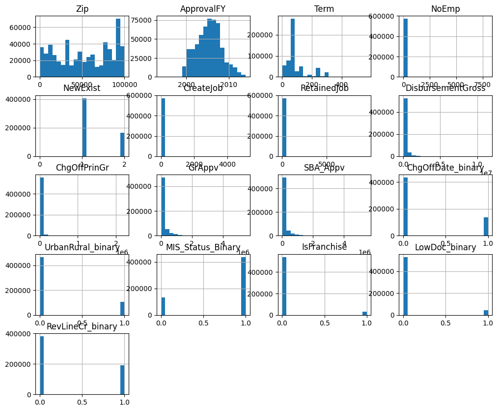

```python
#create a histogram for bumeric variables with bins of 20
df.hist(figsize=(12, 10), bins=20)
```

ii. Historgram of Loan approval by year

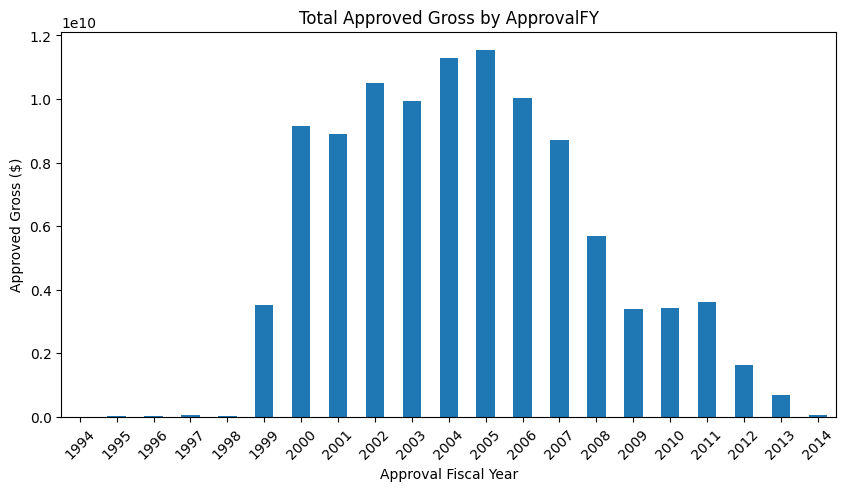

```python
 # Ensure ApprovalFY is numeric
df['ApprovalFY'] = pd.to_numeric(df['ApprovalFY'], errors='coerce')

# Drop any NaN values that might have been introduced during conversion
df = df.dropna(subset=['ApprovalFY'])

# Aggregate and plot
df.groupby('ApprovalFY')['GrAppv'].sum().plot(kind='bar', figsize=(10, 5))

plt.xlabel("Approval Fiscal Year")
plt.ylabel("Approved Gross ($)")
plt.title("Total Approved Gross by ApprovalFY")
plt.xticks(rotation=45)
plt.show()
```

The peak of loan approval was 2005

iii. Histogram of loan disbursement by year

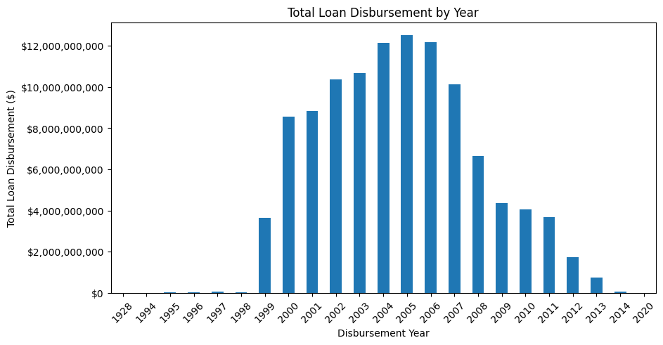

```python
# Extract the last two digits (year) from DisbursementDate and convert to integer
df['DisbursementYear'] = df['DisbursementDate'].str[-2:].astype(int)

# Fix potential century issue: Convert 00-23 to 2000-2023, and 80-99 to 1980-1999
df['DisbursementYear'] = df['DisbursementYear'].apply(lambda x: x + 2000 if x < 24 else x + 1900)

# Aggregate total disbursement by year
yearly_disbursement = df.groupby('DisbursementYear')['DisbursementGross'].sum()

# Plot
fig, ax = plt.subplots(figsize=(10, 5))
yearly_disbursement.plot(kind='bar', ax=ax)

# Formatting
ax.set_xlabel("Disbursement Year")
ax.set_ylabel("Total Loan Disbursement ($)")
ax.set_title("Total Loan Disbursement by Year")
ax.yaxis.set_major_formatter(mtick.StrMethodFormatter('${x:,.0f}'))  # Format as dollars
plt.xticks(rotation=45)

plt.show()
```

The peak of loan disbursement year was 2005 matching the year that had the highest loan approval

Box plots for outliers and distributions

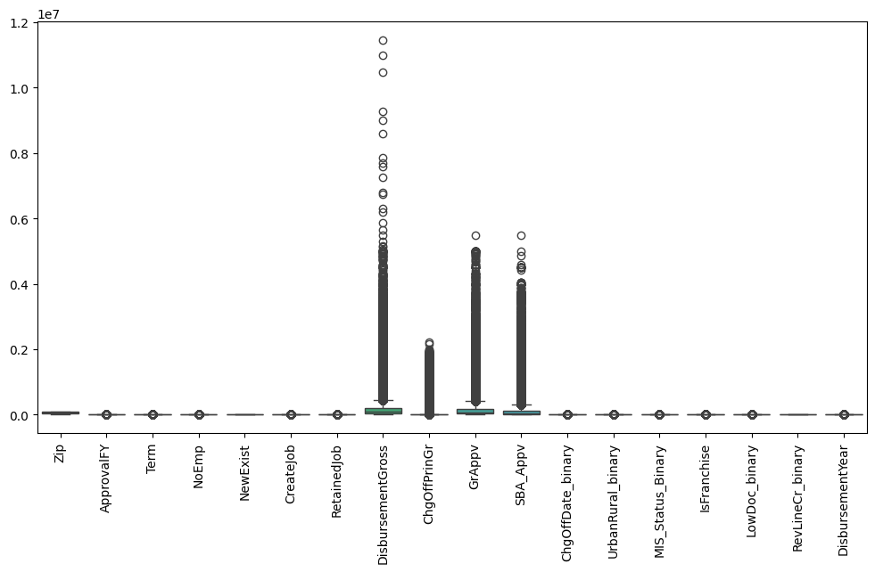

```python
#box plotting
plt.figure(figsize=(12, 6))
sns.boxplot(data=df.select_dtypes(include=['number']))
plt.xticks(rotation=90)
plt.show()
```

Check current columns

```python
#check columns
df.columns
```

```
Index(['Name', 'City', 'State', 'Zip', 'Bank', 'BankState', 'ApprovalDate',
       'ApprovalFY', 'Term', 'NoEmp', 'NewExist', 'CreateJob', 'RetainedJob',
       'DisbursementDate', 'DisbursementGross', 'BalanceGross', 'ChgOffPrinGr',
       'GrAppv', 'SBA_Appv', 'ChgOffDate_binary', 'UrbanRural_binary',
       'MIS_Status_Binary', 'IsFranchise', 'LowDoc_binary', 'RevLineCr_binary',
       'Sector_Accommodation & Food', 'Sector_Admin & Waste Mgmt',
       'Sector_Agriculture', 'Sector_Arts & Recreation', 'Sector_Construction',
       'Sector_Education', 'Sector_Finance', 'Sector_Healthcare',
       'Sector_Information', 'Sector_Management', 'Sector_Manufacturing',
       'Sector_Mining', 'Sector_Other Services',
       'Sector_Professional Services', 'Sector_Public Admin',
       'Sector_Real Estate', 'Sector_Retail Trade', 'Sector_Transportation',
       'Sector_Unknown', 'Sector_Utilities', 'Sector_Wholesale Trade',
       'DisbursementYear'],
      dtype='object')
```

## 1. Continuous Variables

### A. Predicting Gross Approved Loan (GrAppv)

```python
#set features and target
features = ['Term', 'NoEmp', 'NewExist', 'CreateJob', 'RetainedJob', 'DisbursementGross', 'ChgOffPrinGr', 'SBA_Appv',
            'ChgOffDate_binary', 'UrbanRural_binary', 'MIS_Status_Binary',
            'IsFranchise', 'LowDoc_binary', 'RevLineCr_binary',
            'Sector_Accommodation & Food', 'Sector_Admin & Waste Mgmt',
            'Sector_Agriculture', 'Sector_Arts & Recreation', 'Sector_Construction',
            'Sector_Education', 'Sector_Finance', 'Sector_Healthcare',
            'Sector_Information', 'Sector_Management', 'Sector_Manufacturing',
            'Sector_Mining', 'Sector_Other Services', 'Sector_Professional Services',
            'Sector_Public Admin', 'Sector_Real Estate', 'Sector_Retail Trade',
            'Sector_Transportation', 'Sector_Unknown', 'Sector_Utilities',
            'Sector_Wholesale Trade']

X = df[features]
y = df['GrAppv']

#Split into 80% train+val, 20% test
X_train_val, X_test, y_train_val, y_test = train_test_split(X, y, test_size=0.20, random_state=42)

#Split train_val into 87.5% train, 12.5% val ( to achieve 70% train, 10% val)
X_train, X_val, y_train, y_val = train_test_split(X_train_val, y_train_val, test_size=0.125, random_state=42)
```

i) Linear Regression

```
Train MSE: 1989391154.14, R²: 0.9783
Validation MSE: 1794591167.47, R²: 0.9802
Test MSE: 1981584865.49, R²: 0.9785
```

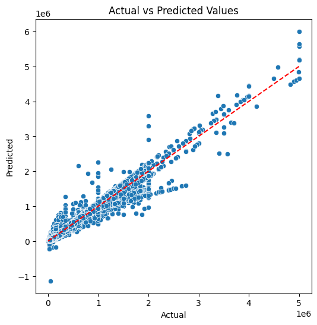

```python
#Scale features for standardization
scaler = StandardScaler()
X_train_scaled = scaler.fit_transform(X_train)
X_val_scaled = scaler.transform(X_val)
X_test_scaled = scaler.transform(X_test)

# Fit Linear Regression Model
lin_reg = LinearRegression()
lin_reg.fit(X_train_scaled, y_train)

# Predict
y_train_pred = lin_reg.predict(X_train_scaled)
y_val_pred = lin_reg.predict(X_val_scaled)
y_test_pred = lin_reg.predict(X_test_scaled)

# Evaluate
def evaluate(y_true, y_pred, label=""):
    mse = mean_squared_error(y_true, y_pred)
    r2 = r2_score(y_true, y_pred)
    print(f"{label} MSE: {mse:.2f}, R²: {r2:.4f}")

evaluate(y_train, y_train_pred, "Train")
evaluate(y_val, y_val_pred, "Validation")
evaluate(y_test, y_test_pred, "Test")

#save predictions
y_test_pred_lr = y_test_pred


# Scatter plot of actual vs predicted
plt.figure(figsize=(6,6))
sns.scatterplot(x=y_test, y=y_test_pred)
plt.xlabel("Actual")
plt.ylabel("Predicted")
plt.title("Actual vs Predicted Values")
plt.plot([y_test.min(), y_test.max()], [y_test.min(), y_test.max()], 'r--')  # diagonal line
plt.show()
```

ii) Random Forest

```python
# Train Random Forest Regressor with scaled data
rf_model = RandomForestRegressor(
    n_estimators=100,
    max_depth=10,
    n_jobs=-1,
    random_state=42
)
# Use scaled features
rf_model.fit(X_train_scaled, y_train)

# Predictions
y_train_pred_rf = rf_model.predict(X_train_scaled)
y_val_pred_rf = rf_model.predict(X_val_scaled)
y_test_pred_rf = rf_model.predict(X_test_scaled)

# Evaluate model performance
train_mse_rf = mean_squared_error(y_train, y_train_pred_rf)
val_mse_rf = mean_squared_error(y_val, y_val_pred_rf)
test_mse_rf = mean_squared_error(y_test, y_test_pred_rf)

train_r2_rf = r2_score(y_train, y_train_pred_rf)
val_r2_rf = r2_score(y_val, y_val_pred_rf)
test_r2_rf = r2_score(y_test, y_test_pred_rf)

# Print results
print(f"Random Forest Train MSE: {train_mse_rf:.4f}, R²: {train_r2_rf:.4f}")
print(f"Random Forest Validation MSE: {val_mse_rf:.4f}, R²: {val_r2_rf:.4f}")
print(f"Random Forest Test MSE: {test_mse_rf:.4f}, R²: {test_r2_rf:.4f}")

#save predictions
y_test_pred_rf = rf_model.predict(X_test_scaled)
```

```
Random Forest Train MSE: 129422729.8295, R²: 0.9986
Random Forest Validation MSE: 246892299.9305, R²: 0.9973
Random Forest Test MSE: 259425575.0244, R²: 0.9972
```

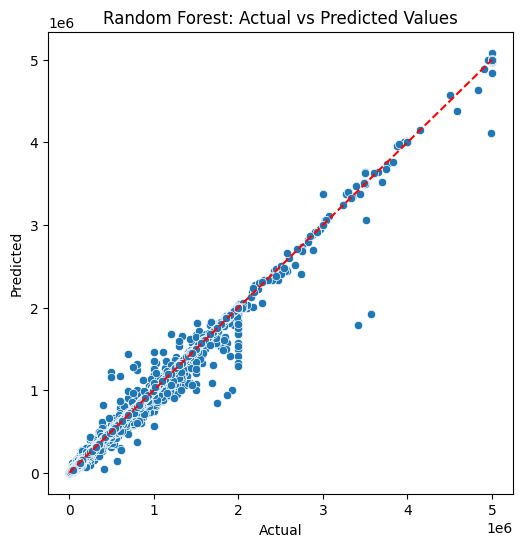

```python
# Scatter plot of actual vs predicted for Random Forest
plt.figure(figsize=(6,6))
sns.scatterplot(x=y_test, y=y_test_pred_rf)
plt.xlabel("Actual")
plt.ylabel("Predicted")
plt.title("Random Forest: Actual vs Predicted Values")
plt.plot([y_test.min(), y_test.max()], [y_test.min(), y_test.max()], 'r--')  # diagonal line
plt.show()
```

iii) XG Boost

```python
# Train XGBoost Regressor
xgb_model = XGBRegressor(n_estimators=50, random_state=42, eval_metric="rmse", n_jobs=-1)
xgb_model.fit(X_train, y_train)

# Predictions
y_train_pred = xgb_model.predict(X_train)
y_val_pred = xgb_model.predict(X_val)
y_test_pred = xgb_model.predict(X_test)

# Evaluate model performance
train_mse = mean_squared_error(y_train, y_train_pred)
val_mse = mean_squared_error(y_val, y_val_pred)
test_mse = mean_squared_error(y_test, y_test_pred)

train_r2 = r2_score(y_train, y_train_pred)
val_r2 = r2_score(y_val, y_val_pred)
test_r2 = r2_score(y_test, y_test_pred)

# Print results
print(f"Train MSE: {train_mse:.4f}, R²: {train_r2:.4f}")
print(f"Validation MSE: {val_mse:.4f}, R²: {val_r2:.4f}")
print(f"Test MSE: {test_mse:.4f}, R²: {test_r2:.4f}")


#save predictions
y_test_pred_xgb = xgb_model.predict(X_test)
```

```
Train MSE: 1075209796.1439, R²: 0.9883
Validation MSE: 1834541327.1724, R²: 0.9798
Test MSE: 1923854431.4823, R²: 0.9791
```

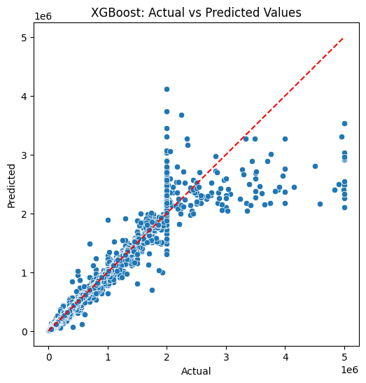

```python
# Scatter plot of actual vs predicted for XGBoost
plt.figure(figsize=(6,6))
sns.scatterplot(x=y_test, y=y_test_pred)
plt.xlabel("Actual")
plt.ylabel("Predicted")
plt.title("XGBoost: Actual vs Predicted Values")
plt.plot([y_test.min(), y_test.max()], [y_test.min(), y_test.max()], 'r--')  # diagonal line
plt.show()
```

iv) Support Machine Vectors

```python
# Create a pipeline with StandardScaler, PCA, and LinearSVR
svr_pipeline = make_pipeline(
    StandardScaler(),
    PCA(n_components=0.95),  # Retain 95% of variance
    LinearSVR(random_state=42, max_iter=10000)
)

# Fit model on training data
svr_pipeline.fit(X_train, y_train)

# Predictions
y_train_pred = svr_pipeline.predict(X_train)
y_val_pred = svr_pipeline.predict(X_val)
y_test_pred = svr_pipeline.predict(X_test)

# Evaluate model performance
train_mse = mean_squared_error(y_train, y_train_pred)
val_mse = mean_squared_error(y_val, y_val_pred)
test_mse = mean_squared_error(y_test, y_test_pred)

train_r2 = r2_score(y_train, y_train_pred)
val_r2 = r2_score(y_val, y_val_pred)
test_r2 = r2_score(y_test, y_test_pred)

# Print results
print(f"Train MSE: {train_mse:.4f}, R²: {train_r2:.4f}")
print(f"Validation MSE: {val_mse:.4f}, R²: {val_r2:.4f}")
print(f"Test MSE: {test_mse:.4f}, R²: {test_r2:.4f}")

#save predictions
y_test_pred_svr = svr_pipeline.predict(X_test)
```

```
Train MSE: 21029628772.2606, R²: 0.7705
Validation MSE: 20930006005.8791, R²: 0.7696
Test MSE: 21209814478.5109, R²: 0.7695
```

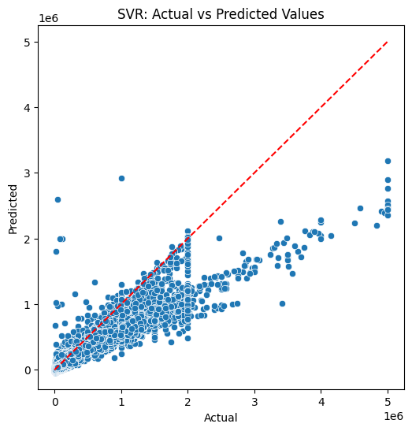

```python
# Scatter plot of actual vs predicted for SVR
plt.figure(figsize=(6,6))
sns.scatterplot(x=y_test, y=y_test_pred)
plt.xlabel("Actual")
plt.ylabel("Predicted")
plt.title("SVR: Actual vs Predicted Values")
plt.plot([y_test.min(), y_test.max()], [y_test.min(), y_test.max()], 'r--')  # diagonal line
plt.show()
```

```python
# Create a dictionary of results
results_apprv = {
    'Model': ['Linear Regression', 'Random Forest', 'XGBoost', 'Linear SVM (10%)'],
    'Train MSE': [1989391154.14, 129422729.8295, 1075209796.1439, 21029628772.2606],
    'Train R²': [0.9783, 0.9986, 0.9883, 0.7705],
    'Val MSE': [1794591167.47, 246892299.9305, 1834541327.1724, 20930006005.8791],
    'Val R²': [0.9802, 0.9973, 0.9798, 0.7696],
    'Test MSE': [1981584865.49, 259425575.0244, 1923854431.4823, 21209814478.5109],
    'Test R²': [0.9785, 0.9972, 0.9791, 0.7695]
}

# Convert to DataFrame
results_df = pd.DataFrame(results_apprv)

# Display it
results_df
```

|  | Model | Train MSE | Train R² | Val MSE | Val R² | Test MSE | Test R² |
| --- | --- | --- | --- | --- | --- | --- | --- |
| 0 | Linear Regression | 1.989391e+09 | 0.9783 | 1.794591e+09 | 0.9802 | 1.981585e+09 | 0.9785 |
| 1 | Random Forest | 1.294227e+08 | 0.9986 | 2.468923e+08 | 0.9973 | 2.594256e+08 | 0.9972 |
| 2 | XGBoost | 1.075210e+09 | 0.9883 | 1.834541e+09 | 0.9798 | 1.923854e+09 | 0.9791 |
| 3 | Linear SVM (10%) | 2.102963e+10 | 0.7705 | 2.093001e+10 | 0.7696 | 2.120981e+10 | 0.7695 |

### Feature importance

Since Random Forest is the best performing model, we wil use its results in shap to identify most-important features

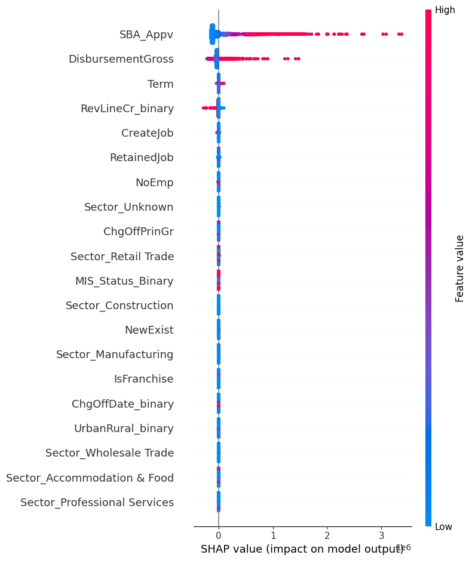

```python
# Initialize the SHAP explainer
explainer_rf = shap.TreeExplainer(rf_model)

# Calculate 5% of the training data size
sample_size = int(0.05 * X_train_scaled.shape[0])

# Randomly select 1% of indices
sample_indices = np.random.choice(X_train_scaled.shape[0], size=sample_size, replace=False)

# Subset scaled data
X_sample_scaled = X_train_scaled[sample_indices]

# Convert to DataFrame with feature names
X_sample_df = pd.DataFrame(X_sample_scaled, columns=X_train.columns)

# Compute SHAP values for the 1% sample
shap_values_rf = explainer_rf.shap_values(X_sample_scaled)

# Display the summary plot with actual feature names
shap.summary_plot(shap_values_rf, X_sample_df)
```

From this plot, the leading features influencing the gross approved loans the size of SBA loan approved, the amount disbursed, loan term, and revolving line of credit. The first two features can be argued as correlation with the target variable as the size of SBA loan approved is directly correlated with the the final amount that is approved based on SBA guideline (85% for loans upto USD 150,000 and 75% for loans above USD 150,000). Also, the amount disbursed is directly dependendent on how much is approved.

Loan term has a positive impact on the amount of loan approved while revolving line of credit has a high negative impact on predicting gross approved loan.

### B. Predicting the Amount of Charged-Off Principal

Understanding what factors contribute to larger charge-offs can help refine lending policies.

```python
# Define features and target variable
features = ['NoEmp', 'NewExist', 'DisbursementGross', 'GrAppv', 'SBA_Appv', 'UrbanRural_binary', 'MIS_Status_Binary',
            'IsFranchise', 'LowDoc_binary', 'RevLineCr_binary',
            'Sector_Accommodation & Food', 'Sector_Admin & Waste Mgmt',
            'Sector_Agriculture', 'Sector_Arts & Recreation', 'Sector_Construction',
            'Sector_Education', 'Sector_Finance', 'Sector_Healthcare',
            'Sector_Information', 'Sector_Management', 'Sector_Manufacturing',
            'Sector_Mining', 'Sector_Other Services', 'Sector_Professional Services',
            'Sector_Public Admin', 'Sector_Real Estate', 'Sector_Retail Trade',
            'Sector_Transportation', 'Sector_Unknown', 'Sector_Utilities',
            'Sector_Wholesale Trade']

X = df[features]
y = df['ChgOffPrinGr']

# Split data into 80% train+val and 20% test
X_train_val_prin, X_test_prin, y_train_val_prin, y_test_prin = train_test_split(X, y, test_size=0.20, random_state=42)

# Split train+val into 70% train and 10% val (which is 0.125 of 80%)
X_train_prin, X_val_prin, y_train_prin, y_val_prin = train_test_split(X_train_val_prin, y_train_val_prin, test_size=0.125, random_state=42)
```

i) Linear Regression as base model

```
Train MSE: 3951924938.0516, R²: 0.2622
Validation MSE: 4257093285.2348, R²: 0.2606
Test MSE: 4052395221.0307, R²: 0.2626
```

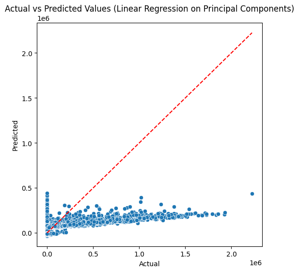

```python
# Standardize the features
scaler_prin = StandardScaler()
X_train_scaled_prin = scaler_prin.fit_transform(X_train_prin)
X_val_scaled_prin = scaler_prin.transform(X_val_prin)
X_test_scaled_prin = scaler_prin.transform(X_test_prin)

# Train Linear Regression model
lr_model_prin = LinearRegression()
lr_model_prin.fit(X_train_scaled_prin, y_train_prin)

# Predictions
y_train_pred_prin = lr_model_prin.predict(X_train_scaled_prin)
y_val_pred_prin = lr_model_prin.predict(X_val_scaled_prin)
y_test_pred_prin = lr_model_prin.predict(X_test_scaled_prin)

# Evaluate model performance
train_mse_prin = mean_squared_error(y_train_prin, y_train_pred_prin)
val_mse_prin = mean_squared_error(y_val_prin, y_val_pred_prin)
test_mse_prin = mean_squared_error(y_test_prin, y_test_pred_prin)

train_r2_prin = r2_score(y_train_prin, y_train_pred_prin)
val_r2_prin = r2_score(y_val_prin, y_val_pred_prin)
test_r2_prin = r2_score(y_test_prin, y_test_pred_prin)

# Print results
print(f"Train MSE: {train_mse_prin:.4f}, R²: {train_r2_prin:.4f}")
print(f"Validation MSE: {val_mse_prin:.4f}, R²: {val_r2_prin:.4f}")
print(f"Test MSE: {test_mse_prin:.4f}, R²: {test_r2_prin:.4f}")

# Plot Actual vs Predicted for test set
plt.figure(figsize=(6,6))
sns.scatterplot(x=y_test_prin, y=y_test_pred_prin)
plt.xlabel("Actual")
plt.ylabel("Predicted")
plt.title("Actual vs Predicted Values (Linear Regression on Principal Components)")
plt.plot([y_test_prin.min(), y_test_prin.max()], [y_test_prin.min(), y_test_prin.max()], 'r--')  # diagonal line
plt.show()
```

ii) Random Forest

```python
# Train Random Forest model on _prin split
rf_model_prin = RandomForestRegressor(n_estimators=10, random_state=42)
rf_model_prin.fit(X_train_prin, y_train_prin)

# Predictions
y_train_pred_prin = rf_model_prin.predict(X_train_prin)
y_val_pred_prin = rf_model_prin.predict(X_val_prin)
y_test_pred_prin = rf_model_prin.predict(X_test_prin)

# Evaluate performance
train_mse_prin = mean_squared_error(y_train_prin, y_train_pred_prin)
val_mse_prin = mean_squared_error(y_val_prin, y_val_pred_prin)
test_mse_prin = mean_squared_error(y_test_prin, y_test_pred_prin)

train_rmse_prin = np.sqrt(train_mse_prin)
val_rmse_prin = np.sqrt(val_mse_prin)
test_rmse_prin = np.sqrt(test_mse_prin)

train_r2_prin = r2_score(y_train_prin, y_train_pred_prin)
val_r2_prin = r2_score(y_val_prin, y_val_pred_prin)
test_r2_prin = r2_score(y_test_prin, y_test_pred_prin)

# Print results
print(f"Train RMSE: {train_rmse_prin:.4f}, R²: {train_r2_prin:.4f}")
print(f"Validation RMSE: {val_rmse_prin:.4f}, R²: {val_r2_prin:.4f}")
print(f"Test RMSE: {test_rmse_prin:.4f}, R²: {test_r2_prin:.4f}")

#save predictions
y_test_pred_prin = rf_model_prin.predict(X_test_prin)
```

```
Train RMSE: 13003.0535, R²: 0.9684
Validation RMSE: 32454.0521, R²: 0.8171
Test RMSE: 29366.0614, R²: 0.8431
```

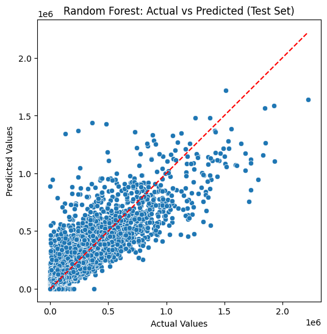

```python
#plot actural versus prediced for train
plt.figure(figsize=(6, 6))
sns.scatterplot(x=y_test_prin, y=y_test_pred_prin)
plt.xlabel("Actual Values")
plt.ylabel("Predicted Values")
plt.title("Random Forest: Actual vs Predicted (Test Set)")
plt.plot([y_test_prin.min(), y_test_prin.max()],
         [y_test_prin.min(), y_test_prin.max()],
         'r--')
plt.show()
```

iii) XG Boost

Use XGBoost Regressor because 'ChgOffPrinGr' is a continuous variable

```python
# Train XGBoost model on _prin split
xgb_model_prin = XGBRegressor(n_estimators=50, random_state=42, eval_metric="rmse", n_jobs=-1)
xgb_model_prin.fit(X_train_prin, y_train_prin)

# Predictions
y_train_pred_prin = xgb_model_prin.predict(X_train_prin)
y_val_pred_prin = xgb_model_prin.predict(X_val_prin)
y_test_pred_prin = xgb_model_prin.predict(X_test_prin)

# Evaluate model performance
train_mse_prin = mean_squared_error(y_train_prin, y_train_pred_prin)
val_mse_prin = mean_squared_error(y_val_prin, y_val_pred_prin)
test_mse_prin = mean_squared_error(y_test_prin, y_test_pred_prin)

train_r2_prin = r2_score(y_train_prin, y_train_pred_prin)
val_r2_prin = r2_score(y_val_prin, y_val_pred_prin)
test_r2_prin = r2_score(y_test_prin, y_test_pred_prin)

# Print results
print(f"Train MSE: {train_mse_prin:.4f}, R²: {train_r2_prin:.4f}")
print(f"Validation MSE: {val_mse_prin:.4f}, R²: {val_r2_prin:.4f}")
print(f"Test MSE: {test_mse_prin:.4f}, R²: {test_r2_prin:.4f}")
```

```
Train MSE: 545313973.2197, R²: 0.8982
Validation MSE: 1000066416.2729, R²: 0.8263
Test MSE: 752650245.9733, R²: 0.8630
```

[figure not shown]

```python
#plot actural vs predicetd reslts
plt.figure(figsize=(6, 6))
sns.scatterplot(x=y_test_prin, y=y_test_pred_prin)
plt.xlabel("Actual Values")
plt.ylabel("Predicted Values")
plt.title("XGBoost: Actual vs Predicted (Test Set)")
plt.plot([y_test_prin.min(), y_test_prin.max()],
         [y_test_prin.min(), y_test_prin.max()],
         'r--')
plt.show()
```

iv) SVM

Since SVM is computationally expensive, I will sub-sample 2% of the dataset and gauge its performance.

```python
# Subsample 2% of the training data
X_train_sub_prin, _, y_train_sub_prin, _ = train_test_split(X_train_prin, y_train_prin, train_size=0.02, random_state=42, shuffle=True)

# Standardize the features
scaler_prin = StandardScaler()
X_train_sub_scaled_prin = scaler_prin.fit_transform(X_train_sub_prin)
X_val_scaled_prin = scaler_prin.transform(X_val_prin)
X_test_scaled_prin = scaler_prin.transform(X_test_prin)

# Train Linear SVM model (classification — if continuous target, use SVR instead)
svm_model_prin = LinearSVC(max_iter=1000, random_state=42)
svm_model_prin.fit(X_train_sub_scaled_prin, y_train_sub_prin)

# Predictions
y_train_pred_prin = svm_model_prin.predict(X_train_sub_scaled_prin)
y_val_pred_prin = svm_model_prin.predict(X_val_scaled_prin)
y_test_pred_prin = svm_model_prin.predict(X_test_scaled_prin)

# Evaluate model performance
train_mse_prin = mean_squared_error(y_train_sub_prin, y_train_pred_prin)
val_mse_prin = mean_squared_error(y_val_prin, y_val_pred_prin)
test_mse_prin = mean_squared_error(y_test_prin, y_test_pred_prin)

train_r2_prin = r2_score(y_train_sub_prin, y_train_pred_prin)
val_r2_prin = r2_score(y_val_prin, y_val_pred_prin)
test_r2_prin = r2_score(y_test_prin, y_test_pred_prin)

# Print results
print(f"Train MSE: {train_mse_prin:.4f}, R²: {train_r2_prin:.4f}")
print(f"Validation MSE: {val_mse_prin:.4f}, R²: {val_r2_prin:.4f}")
print(f"Test MSE: {test_mse_prin:.4f}, R²: {test_r2_prin:.4f}")
```

```
Train MSE: 10889396403.4802, R²: -0.7378
Validation MSE: 11950641000.6477, R²: -1.0756
Test MSE: 11890937938.6569, R²: -1.1637
```

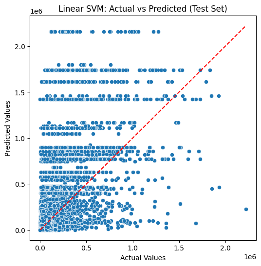

```python
#plot the results
plt.figure(figsize=(6, 6))
sns.scatterplot(x=y_test_prin, y=y_test_pred_prin)
plt.xlabel("Actual Values")
plt.ylabel("Predicted Values")
plt.title("Linear SVM: Actual vs Predicted (Test Set)")
plt.plot([y_test_prin.min(), y_test_prin.max()],
         [y_test_prin.min(), y_test_prin.max()],
         'r--')
plt.show()
```